# Barbod Khaleghi- Project 2C

## Project 2C

Barbod Khaleghi

Below, I performed pairwise sequence alignment. Here, I was able to get both the COVID and FLU proteins and compare them using methods of alignment to set up for further analysis. I have not yet fully developed the descriptions for the code below but I will refine the code and written statements by the time for the final draft.

```python
from Bio import pairwise2
```

```python
from Bio.Seq import Seq
FLU = Seq('GSHHHHHHHHGSGSMENFVRTNFNPMILERAEKTMKEYGENPQNEGNKFAAISTHMEVCF…')
COVID = Seq("AIASEFSSLPSYAAFATAQEAYEQAVANGDSEVVLKKLKKSLNVAKSEFDRDAAMQRKLEKMADQAMTQMYKQARSEDKRAKVTSAMQTMLFTMLRKLDNDALNNIINNARDGCVPLNIIPLTTAAKLMVVIPDYNTYKNTCDGTTFTYASALWEIQQVVDADSKIVQLSEISMDNSPNLAWPLIVTALRANSAVKLQ")
```

```python
alignments = pairwise2.align.globalxx(FLU, COVID)
alignments
```

```
[Alignment(seqA='GSHHHHHHHHGSG---SMENFVRTNFNPMI--LERAEKTMKEYGENPQNEGNKFAAISTHMEVCFMYSDFH--FIDLEGN-TIVKENDDDNAMLKHRF-EII--EGQERNIAWTIV-N--SICNMTENSKPRFLPD--LYDYKTNKFIEIGVTRR-KVEDYYYEKASKLKGENVYIHIFSFDGEEMATDD--EYIL-DEESR-A---RIKTRLFVLRQELAT--AGLWDSFRQSEKGEETLEEEFSYPPTFQRLAN--QSLPPSFKD-YHQFK-AYVS-SFKA…
 Alignment(seqA='GSHHHHHHHHGSG--SMENFVRTNFNPMI--LERAEKTMKEYGENPQNEGNKFAAISTHMEVCFMYSDFH--FIDLEGN-TIVKENDDDNAMLKHRF-EII--EGQERNIAWTIV-N--SICNMTENSKPRFLPD--LYDYKTNKFIEIGVTRR-KVEDYYYEKASKLKGENVYIHIFSFDGEEMATDD--EYIL-DEESR-A---RIKTRLFVLRQELAT--AGLWDSFRQSEKGEETLEEEFSYPPTFQRLAN--QSLPPSFKD-YHQFK-AYVS-SFKAN…
 Alignment(seqA='GSHHHHHHHHGSG--SMENFVRTNFNPMI--LERAEKTMKEYGENPQNEGNKFAAISTHMEVCFMYSDFH--FIDLEGN-TIVKENDDDNAMLKHRF-EII--EGQERNIAWTIV-N--SICNMTENSKPRFLPD--LYDYKTNKFIEIGVTRR-KVEDYYYEKASKLKGENVYIHIFSFDGEEMATDD--EYIL-DEESR-A---RIKTRLFVLRQELAT--AGLWDSFRQSEKGEETLEEEFSYPPTFQRLAN--QSLPPSFKD-YHQFK-AYVS-SFKAN…
 Alignment(seqA='GSHHHHHHHHGSG--SMENFVRTNFNPMI--LERAEKTMKEYGENPQNEGNKFAAISTHMEVCFMYSDFH--FIDLEGN-TIVKENDDDNAMLKHRF-EII--EGQERNIAWTIV-N--SICNMTENSKPRFLPD--LYDYKTNKFIEIGVTRR-KVEDYYYEKASKLKGENVYIHIFSFDGEEMATDD--EYIL-DEESR-A---RIKTRLFVLRQELAT--AGLWDSFRQSEKGEETLEEEFSYPPTFQRLAN--QSLPPSFKD-YHQFK-AYVS-SFKAN…
 Alignment(seqA='GSHHHHHHHHGSG--SMENFVRTNFNPMI--LERAEKTMKEYGENPQNEGNKFAAISTHMEVCFMYSDFH--FIDLEGN-TIVKENDDDNAMLKHRF-EII--EGQERNIAWTIV-N--SICNMTENSKPRFLPD--LYDYKTNKFIEIGVTRR-KVEDYYYEKASKLKGENVYIHIFSFDGEEMATDD--EYIL-DEESR-A---RIKTRLFVLRQELAT--AGLWDSFRQSEKGEETLEEEFSYPPTFQRLAN--QSLPPSFKD-YHQFK-AYVS-SFKAN…
 Alignment(seqA='GSHHHHHHHHGSG--SMENFVRTNFNPMI--LERAEKTMKEYGENPQNEGNKFAAISTHMEVCFMYSDFH--FIDLEGN-TIVKENDDDNAMLKHRF-EII--EGQERNIAWTIV-N--SICNMTENSKPRFLPD--LYDYKTNKFIEIGVTRR-KVEDYYYEKASKLKGENVYIHIFSFDGEEMATDD--EYIL-DEESR-A---RIKTRLFVLRQELAT--AGLWDSFRQSEKGEETLEEEFSYPPTFQRLAN--QSLPPSFKD-YHQFK-AYVS-SFKAN…
 Alignment(seqA='GSHHHHHHHHGSG--SMENFVRTNFNPMI--LERAEKTMKEYGENPQNEGNKFAAISTHMEVCFMYSDFH--FIDLEGN-TIVKENDDDNAMLKHRF-EII--EGQERNIAWTIV-N--SICNMTENSKPRFLPD--LYDYKTNKFIEIGVTRR-KVEDYYYEKASKLKGENVYIHIFSFDGEEMATDD--EYIL-DEESR-A---RIKTRLFVLRQELAT--AGLWDSFRQSEKGEETLEEEFSYPPTFQRLAN--QSLPPSFKD-YHQFK-AYVS-SFKAN…
 Alignment(seqA='GSHHHHHHHHGSG--SMENFVRTNFNPMI--LERAEKTMKEYGENPQNEGNKFAAISTHMEVCFMYSDFH--FIDLEGN-TIVKENDDDNAMLKHRF-EII--EGQERNIAWTIV-N--SICNMTENSKPRFLPD--LYDYKTNKFIEIGVTRR-KVEDYYYEKASKLKGENVYIHIFSFDGEEMATDD--EYIL-DEESR-A---RIKTRLFVLRQELAT--AGLWDSFRQSEKGEETLEEEFSYPPTFQRLAN--QSLPPSFKD-YHQFK-AYVS-SFKAN…
 Alignment(seqA='GSHHHHHHHHGSG--SMENFVRTNFNPMI--LERAEKTMKEYGENPQNEGNKFAAISTHMEVCFMYSDFH--FIDLEGN-TIVKENDDDNAMLKHRF-EII--EGQERNIAWTIV-N--SICNMTENSKPRFLPD--LYDYKTNKFIEIGVTRR-KVEDYYYEKASKLKGENVYIHIFSFDGEEMATDD--EYIL-DEESR-A---RIKTRLFVLRQELAT--AGLWDSFRQSEKGEETLEEEFSYPPTFQRLAN--QSLPPSFKD-YHQFK-AYVS-SFKAN…
 Alignment(seqA='GSHHHHHHHHGSG--SMENFVRTNFNPMI--LERAEKTMKEYGENPQNEGNKFAAISTHMEVCFMYSDFH--FIDLEGN-TIVKENDDDNAMLKHRF-EII--EGQERNIAWTIV-N--SICNMTENSKPRFLPD--LYDYKTNKFIEIGVTRR-KVEDYYYEKASKLKGENVYIHIFSFDGEEMATDD--EYIL-DEESR-A---RIKTRLFVLRQELAT--AGLWDSFRQSEKGEETLEEEFSYPPTFQRLAN--QSLPPSFKD-YHQFK-AYVS-SFKAN…
 Alignment(seqA='GSHHHHHHHHGSG--SMENFVRTNFNPMI--LERAEKTMKEYGENPQNEGNKFAAISTHMEVCFMYSDFH--FIDLEGN-TIVKENDDDNAMLKHRF-EII--EGQERNIAWTIV-N--SICNMTENSKPRFLPD--LYDYKTNKFIEIGVTRR-KVEDYYYEKASKLKGENVYIHIFSFDGEEMATDD--EYIL-DEESR-A---RIKTRLFVLRQELAT--AGLWDSFRQSEKGEETLEEEFSYPPTFQRLAN--QSLPPSFKD-YHQFK-AYVS-SFKAN…
 Alignment(seqA='GSHHHHHHHHGSG--SMENFVRTNFNPMI--LERAEKTMKEYGENPQNEGNKFAAISTHMEVCFMYSDFH--FIDLEGN-TIVKENDDDNAMLKHRF-EII--EGQERNIAWTIV-N--SICNMTENSKPRFLPD--LYDYKTNKFIEIGVTRR-KVEDYYYEKASKLKGENVYIHIFSFDGEEMATDD--EYIL-DEESR-A---RIKTRLFVLRQELAT--AGLWDSFRQSEKGEETLEEEFSYPPTFQRLAN--QSLPPSFKD-YHQFK-AYVS-SFKAN…
 Alignment(seqA='GSHHHHHHHHGSG--SMENFVRTNFNPMI--LERAEKTMKEYGENPQNEGNKFAAISTHMEVCFMYSDFH--FIDLEGN-TIVKENDDDNAMLKHRF-EII--EGQERNIAWTIV-N--SICNMTENSKPRFLPD--LYDYKTNKFIEIGVTRR-KVEDYYYEKASKLKGENVYIHIFSFDGEEMATDD--EYIL-DEESR-A---RIKTRLFVLRQELAT--AGLWDSFRQSEKGEETLEEEFSYPPTFQRLAN--QSLPPSFKD-YHQFK-AYVS-SFKAN…
 Alignment(seqA='GSHHHHHHHHGSG--SMENFVRTNFNPMI--LERAEKTMKEYGENPQNEGNKFAAISTHMEVCFMYSDFH--FIDLEGN-TIVKENDDDNAMLKHRF-EII--EGQERNIAWTIV-N--SICNMTENSKPRFLPD--LYDYKTNKFIEIGVTRR-KVEDYYYEKASKLKGENVYIHIFSFDGEEMATDD--EYIL-DEESR-A---RIKTRLFVLRQELAT--AGLWDSFRQSEKGEETLEEEFSYPPTFQRLAN--QSLPPSFKD-YHQFK-AYVS-SFKAN…
```

```python
>>> for alignment in alignments:
     print(alignment)

('ACCGGT', 'A-C-GT', 4.0, 0, 6)
('ACCGGT', 'AC--GT', 4.0, 0, 6)
('ACCGGT', 'A-CG-T', 4.0, 0, 6)
('ACCGGT', 'AC-G-T', 4.0, 0, 6)
```

```
Alignment(seqA='GSHHHHHHHHGSG---SMENFVRTNFNPMI--LERAEKTMKEYGENPQNEGNKFAAISTHMEVCFMYSDFH--FIDLEGN-TIVKENDDDNAMLKHRF-EII--EGQERNIAWTIV-N--SICNMTENSKPRFLPD--LYDYKTNKFIEIGVTRR-KVEDYYYEKASKLKGENVYIHIFSFDGEEMATDD--EYIL-DEESR-A---RIKTRLFVLRQELAT--AGLWDSFRQSEKGEETLEEEFSYPPTFQRLAN--QSLPPSFKD-YHQFK-AYVS-SFKAN…
Alignment(seqA='GSHHHHHHHHGSG--SMENFVRTNFNPMI--LERAEKTMKEYGENPQNEGNKFAAISTHMEVCFMYSDFH--FIDLEGN-TIVKENDDDNAMLKHRF-EII--EGQERNIAWTIV-N--SICNMTENSKPRFLPD--LYDYKTNKFIEIGVTRR-KVEDYYYEKASKLKGENVYIHIFSFDGEEMATDD--EYIL-DEESR-A---RIKTRLFVLRQELAT--AGLWDSFRQSEKGEETLEEEFSYPPTFQRLAN--QSLPPSFKD-YHQFK-AYVS-SFKANG…
Alignment(seqA='GSHHHHHHHHGSG--SMENFVRTNFNPMI--LERAEKTMKEYGENPQNEGNKFAAISTHMEVCFMYSDFH--FIDLEGN-TIVKENDDDNAMLKHRF-EII--EGQERNIAWTIV-N--SICNMTENSKPRFLPD--LYDYKTNKFIEIGVTRR-KVEDYYYEKASKLKGENVYIHIFSFDGEEMATDD--EYIL-DEESR-A---RIKTRLFVLRQELAT--AGLWDSFRQSEKGEETLEEEFSYPPTFQRLAN--QSLPPSFKD-YHQFK-AYVS-SFKANG…
Alignment(seqA='GSHHHHHHHHGSG--SMENFVRTNFNPMI--LERAEKTMKEYGENPQNEGNKFAAISTHMEVCFMYSDFH--FIDLEGN-TIVKENDDDNAMLKHRF-EII--EGQERNIAWTIV-N--SICNMTENSKPRFLPD--LYDYKTNKFIEIGVTRR-KVEDYYYEKASKLKGENVYIHIFSFDGEEMATDD--EYIL-DEESR-A---RIKTRLFVLRQELAT--AGLWDSFRQSEKGEETLEEEFSYPPTFQRLAN--QSLPPSFKD-YHQFK-AYVS-SFKANG…
Alignment(seqA='GSHHHHHHHHGSG--SMENFVRTNFNPMI--LERAEKTMKEYGENPQNEGNKFAAISTHMEVCFMYSDFH--FIDLEGN-TIVKENDDDNAMLKHRF-EII--EGQERNIAWTIV-N--SICNMTENSKPRFLPD--LYDYKTNKFIEIGVTRR-KVEDYYYEKASKLKGENVYIHIFSFDGEEMATDD--EYIL-DEESR-A---RIKTRLFVLRQELAT--AGLWDSFRQSEKGEETLEEEFSYPPTFQRLAN--QSLPPSFKD-YHQFK-AYVS-SFKANG…
Alignment(seqA='GSHHHHHHHHGSG--SMENFVRTNFNPMI--LERAEKTMKEYGENPQNEGNKFAAISTHMEVCFMYSDFH--FIDLEGN-TIVKENDDDNAMLKHRF-EII--EGQERNIAWTIV-N--SICNMTENSKPRFLPD--LYDYKTNKFIEIGVTRR-KVEDYYYEKASKLKGENVYIHIFSFDGEEMATDD--EYIL-DEESR-A---RIKTRLFVLRQELAT--AGLWDSFRQSEKGEETLEEEFSYPPTFQRLAN--QSLPPSFKD-YHQFK-AYVS-SFKANG…
Alignment(seqA='GSHHHHHHHHGSG--SMENFVRTNFNPMI--LERAEKTMKEYGENPQNEGNKFAAISTHMEVCFMYSDFH--FIDLEGN-TIVKENDDDNAMLKHRF-EII--EGQERNIAWTIV-N--SICNMTENSKPRFLPD--LYDYKTNKFIEIGVTRR-KVEDYYYEKASKLKGENVYIHIFSFDGEEMATDD--EYIL-DEESR-A---RIKTRLFVLRQELAT--AGLWDSFRQSEKGEETLEEEFSYPPTFQRLAN--QSLPPSFKD-YHQFK-AYVS-SFKANG…
Alignment(seqA='GSHHHHHHHHGSG--SMENFVRTNFNPMI--LERAEKTMKEYGENPQNEGNKFAAISTHMEVCFMYSDFH--FIDLEGN-TIVKENDDDNAMLKHRF-EII--EGQERNIAWTIV-N--SICNMTENSKPRFLPD--LYDYKTNKFIEIGVTRR-KVEDYYYEKASKLKGENVYIHIFSFDGEEMATDD--EYIL-DEESR-A---RIKTRLFVLRQELAT--AGLWDSFRQSEKGEETLEEEFSYPPTFQRLAN--QSLPPSFKD-YHQFK-AYVS-SFKANG…
Alignment(seqA='GSHHHHHHHHGSG--SMENFVRTNFNPMI--LERAEKTMKEYGENPQNEGNKFAAISTHMEVCFMYSDFH--FIDLEGN-TIVKENDDDNAMLKHRF-EII--EGQERNIAWTIV-N--SICNMTENSKPRFLPD--LYDYKTNKFIEIGVTRR-KVEDYYYEKASKLKGENVYIHIFSFDGEEMATDD--EYIL-DEESR-A---RIKTRLFVLRQELAT--AGLWDSFRQSEKGEETLEEEFSYPPTFQRLAN--QSLPPSFKD-YHQFK-AYVS-SFKANG…
Alignment(seqA='GSHHHHHHHHGSG--SMENFVRTNFNPMI--LERAEKTMKEYGENPQNEGNKFAAISTHMEVCFMYSDFH--FIDLEGN-TIVKENDDDNAMLKHRF-EII--EGQERNIAWTIV-N--SICNMTENSKPRFLPD--LYDYKTNKFIEIGVTRR-KVEDYYYEKASKLKGENVYIHIFSFDGEEMATDD--EYIL-DEESR-A---RIKTRLFVLRQELAT--AGLWDSFRQSEKGEETLEEEFSYPPTFQRLAN--QSLPPSFKD-YHQFK-AYVS-SFKANG…
Alignment(seqA='GSHHHHHHHHGSG--SMENFVRTNFNPMI--LERAEKTMKEYGENPQNEGNKFAAISTHMEVCFMYSDFH--FIDLEGN-TIVKENDDDNAMLKHRF-EII--EGQERNIAWTIV-N--SICNMTENSKPRFLPD--LYDYKTNKFIEIGVTRR-KVEDYYYEKASKLKGENVYIHIFSFDGEEMATDD--EYIL-DEESR-A---RIKTRLFVLRQELAT--AGLWDSFRQSEKGEETLEEEFSYPPTFQRLAN--QSLPPSFKD-YHQFK-AYVS-SFKANG…
Alignment(seqA='GSHHHHHHHHGSG--SMENFVRTNFNPMI--LERAEKTMKEYGENPQNEGNKFAAISTHMEVCFMYSDFH--FIDLEGN-TIVKENDDDNAMLKHRF-EII--EGQERNIAWTIV-N--SICNMTENSKPRFLPD--LYDYKTNKFIEIGVTRR-KVEDYYYEKASKLKGENVYIHIFSFDGEEMATDD--EYIL-DEESR-A---RIKTRLFVLRQELAT--AGLWDSFRQSEKGEETLEEEFSYPPTFQRLAN--QSLPPSFKD-YHQFK-AYVS-SFKANG…
Alignment(seqA='GSHHHHHHHHGSG--SMENFVRTNFNPMI--LERAEKTMKEYGENPQNEGNKFAAISTHMEVCFMYSDFH--FIDLEGN-TIVKENDDDNAMLKHRF-EII--EGQERNIAWTIV-N--SICNMTENSKPRFLPD--LYDYKTNKFIEIGVTRR-KVEDYYYEKASKLKGENVYIHIFSFDGEEMATDD--EYIL-DEESR-A---RIKTRLFVLRQELAT--AGLWDSFRQSEKGEETLEEEFSYPPTFQRLAN--QSLPPSFKD-YHQFK-AYVS-SFKANG…
Alignment(seqA='GSHHHHHHHHGSG--SMENFVRTNFNPMI--LERAEKTMKEYGENPQNEGNKFAAISTHMEVCFMYSDFH--FIDLEGN-TIVKENDDDNAMLKHRF-EII--EGQERNIAWTIV-N--SICNMTENSKPRFLPD--LYDYKTNKFIEIGVTRR-KVEDYYYEKASKLKGENVYIHIFSFDGEEMATDD--EYIL-DEESR-A---RIKTRLFVLRQELAT--AGLWDSFRQSEKGEETLEEEFSYPPTFQRLAN--QSLPPSFKD-YHQFK-AYVS-SFKANG…
```

[output not shown]

```python
>>> from Bio.pairwise2 import format_alignment
>>> alignments = pairwise2.align.globalxx(FLU, COVID)
>>> for alignment in alignments:
     print(format_alignment(*alignment))
```

```
GSHHHHHHHHGSG---SMENFVRTNFNPMI--LERAEKTMKEYGENPQNEGNKFAAISTHMEVCFMYSDFH--FIDLEGN-TIVKENDDDNAMLKHRF-EII--EGQERNIAWTIV-N--SICNMTENSKPRFLPD--LYDYKTNKFIEIGVTRR-KVEDYYYEKASKLKGENVYIHIFSFDGEEMATDD--EYIL-DEESR-A---RIKTRLFVLRQELAT--AGLWDSFRQSEKGEETLEEEFSYPPTFQRLAN--QSLPPSFKD-YHQFK-AYVS-SFKANGNIEA-KLG-AMSEKV…
                | |      |      |             |          |        |      |       |         |       |    | |    |   | |  |     |           |   |  |          |       | | |   ||            |     |    |   | |   | |     |  |     |   |                      |  |   |         |   | |    |       |  |   |   ||…
-------------AIAS-E------F----SSL-------------P----------S--------Y----AAF------AT---------A------QE--AYE-Q----A---VANGDS-----E---------VVL---K--K---------LK-------K-S-L---NV------------A---KSE---FD---RDAAMQR-K-----L--E---KMA---D----------------------Q--A-MTQ--------MY---KQA---RS-------E-DK--RA---KV…
  Score=132

GSHHHHHHHHGSG--SMENFVRTNFNPMI--LERAEKTMKEYGENPQNEGNKFAAISTHMEVCFMYSDFH--FIDLEGN-TIVKENDDDNAMLKHRF-EII--EGQERNIAWTIV-N--SICNMTENSKPRFLPD--LYDYKTNKFIEIGVTRR-KVEDYYYEKASKLKGENVYIHIFSFDGEEMATDD--EYIL-DEESR-A---RIKTRLFVLRQELAT--AGLWDSFRQSEKGEETLEEEFSYPPTFQRLAN--QSLPPSFKD-YHQFK-AYVS-SFKANGNIEA-KLG-AMSEKVN…
            .  | |      |      |             |          |        |      |       |         |       |    | |    |   | |  |     |           |   |  |          |       | | |   ||            |     |    |   | |   | |     |  |     |   |                      |  |   |         |   | |    |       |  |   |   || …
------------AIAS-E------F----SSL-------------P----------S--------Y----AAF------AT---------A------QE--AYE-Q----A---VANGDS-----E---------VVL---K--K---------LK-------K-S-L---NV------------A---KSE---FD---RDAAMQR-K-----L--E---KMA---D----------------------Q--A-MTQ--------MY---KQA---RS-------E-DK--RA---KV-…
  Score=132

GSHHHHHHHHGSG--SMENFVRTNFNPMI--LERAEKTMKEYGENPQNEGNKFAAISTHMEVCFMYSDFH--FIDLEGN-TIVKENDDDNAMLKHRF-EII--EGQERNIAWTIV-N--SICNMTENSKPRFLPD--LYDYKTNKFIEIGVTRR-KVEDYYYEKASKLKGENVYIHIFSFDGEEMATDD--EYIL-DEESR-A---RIKTRLFVLRQELAT--AGLWDSFRQSEKGEETLEEEFSYPPTFQRLAN--QSLPPSFKD-YHQFK-AYVS-SFKANGNIEA-KLG-AMSEKVN…
           .   | |      |      |             |          |        |      |       |         |       |    | |    |   | |  |     |           |   |  |          |       | | |   ||            |     |    |   | |   | |     |  |     |   |                      |  |   |         |   | |    |       |  |   |   || …
-----------A-IAS-E------F----SSL-------------P----------S--------Y----AAF------AT---------A------QE--AYE-Q----A---VANGDS-----E---------VVL---K--K---------LK-------K-S-L---NV------------A---KSE---FD---RDAAMQR-K-----L--E---KMA---D----------------------Q--A-MTQ--------MY---KQA---RS-------E-DK--RA---KV-…
  Score=132

GSHHHHHHHHGSG--SMENFVRTNFNPMI--LERAEKTMKEYGENPQNEGNKFAAISTHMEVCFMYSDFH--FIDLEGN-TIVKENDDDNAMLKHRF-EII--EGQERNIAWTIV-N--SICNMTENSKPRFLPD--LYDYKTNKFIEIGVTRR-KVEDYYYEKASKLKGENVYIHIFSFDGEEMATDD--EYIL-DEESR-A---RIKTRLFVLRQELAT--AGLWDSFRQSEKGEETLEEEFSYPPTFQRLAN--QSLPPSFKD-YHQFK-AYVS-SFKANGNIEA-KLG-AMSEKVN…
          .    | |      |      |             |          |        |      |       |         |       |    | |    |   | |  |     |           |   |  |          |       | | |   ||            |     |    |   | |   | |     |  |     |   |                      |  |   |         |   | |    |       |  |   |   || …
----------A--IAS-E------F----SSL-------------P----------S--------Y----AAF------AT---------A------QE--AYE-Q----A---VANGDS-----E---------VVL---K--K---------LK-------K-S-L---NV------------A---KSE---FD---RDAAMQR-K-----L--E---KMA---D----------------------Q--A-MTQ--------MY---KQA---RS-------E-DK--RA---KV-…
  Score=132

GSHHHHHHHHGSG--SMENFVRTNFNPMI--LERAEKTMKEYGENPQNEGNKFAAISTHMEVCFMYSDFH--FIDLEGN-TIVKENDDDNAMLKHRF-EII--EGQERNIAWTIV-N--SICNMTENSKPRFLPD--LYDYKTNKFIEIGVTRR-KVEDYYYEKASKLKGENVYIHIFSFDGEEMATDD--EYIL-DEESR-A---RIKTRLFVLRQELAT--AGLWDSFRQSEKGEETLEEEFSYPPTFQRLAN--QSLPPSFKD-YHQFK-AYVS-SFKANGNIEA-KLG-AMSEKVN…
         .     | |      |      |             |          |        |      |       |         |       |    | |    |   | |  |     |           |   |  |          |       | | |   ||            |     |    |   | |   | |     |  |     |   |                      |  |   |         |   | |    |       |  |   |   || …
---------A---IAS-E------F----SSL-------------P----------S--------Y----AAF------AT---------A------QE--AYE-Q----A---VANGDS-----E---------VVL---K--K---------LK-------K-S-L---NV------------A---KSE---FD---RDAAMQR-K-----L--E---KMA---D----------------------Q--A-MTQ--------MY---KQA---RS-------E-DK--RA---KV-…
  Score=132

GSHHHHHHHHGSG--SMENFVRTNFNPMI--LERAEKTMKEYGENPQNEGNKFAAISTHMEVCFMYSDFH--FIDLEGN-TIVKENDDDNAMLKHRF-EII--EGQERNIAWTIV-N--SICNMTENSKPRFLPD--LYDYKTNKFIEIGVTRR-KVEDYYYEKASKLKGENVYIHIFSFDGEEMATDD--EYIL-DEESR-A---RIKTRLFVLRQELAT--AGLWDSFRQSEKGEETLEEEFSYPPTFQRLAN--QSLPPSFKD-YHQFK-AYVS-SFKANGNIEA-KLG-AMSEKVN…
```

[output cut: 43 more lines]

Below are the pymol images of first the 7JLT of the SARS-COV-2 virus and then second the 4SWB of the influenza Virus.

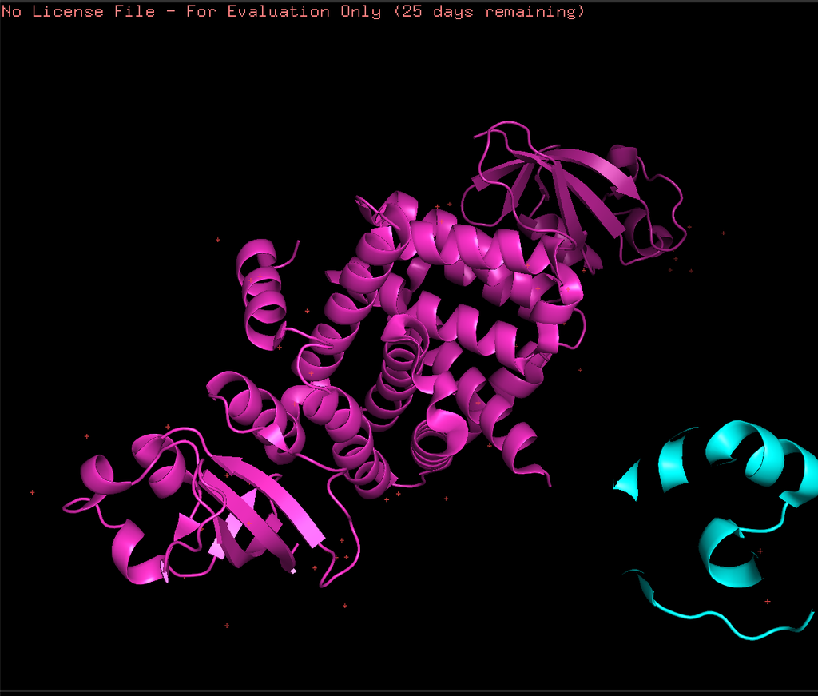

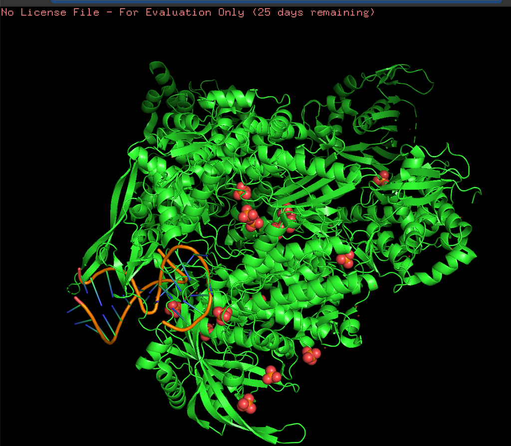

Here, I am using structural bioinformatics.

```python
from Bio.PDB import *
```

```python
import nglview as nv
```

```python
parser = PDBParser()
```

```python
covid_structure = parser.get_structure("7JLT", "7jlt.pdb")
```

```python
flu_structure = parser.get_structure("4WSB", "4wsb.pdb")
```

```python
view = nv.show_biopython(flu_structure)
view
```

```python
view = nv.show_biopython(covid_structure)
view
```

Below, I am trying to develop the sequence logos, however I keep getting the same error. I am not sure why this is the case. I have tried repeatedly with no good result. I will consult with the teacher to try and fix this before the final draft is due.

```python
pip install logomaker
```

```
     |████████████████████████████████| 11.8 MB 3.5 MB/s eta 0:00:01
```

```python
import logomaker
logomaker.demo(COVID)
```

[output not shown]

Here, I am doing the last part of my process which is developing the 3D protein measurements.

```python
import ipywidgets
```

```python
for model in flu_structure:
    for residue in model.get_residues():
        print(residue)
```

[output not shown]

[output cut: 2202 more lines]

```
<Residue   G het=  resseq=5 icode= >
<Residue   U het=  resseq=6 icode= >
<Residue   A het=  resseq=7 icode= >
<Residue   A het=  resseq=8 icode= >
<Residue   C het=  resseq=9 icode= >
<Residue   A het=  resseq=10 icode= >
<Residue   A het=  resseq=11 icode= >
<Residue   G het=  resseq=12 icode= >
<Residue   A het=  resseq=13 icode= >
<Residue   G het=  resseq=14 icode= >
<Residue   G het=  resseq=15 icode= >
<Residue   G het=  resseq=16 icode= >
<Residue HOH het=W resseq=101 icode= >
<Residue HOH het=W resseq=102 icode= >
<Residue HOH het=W resseq=103 icode= >
```

```python
for model in covid_structure:
    for residue in model.get_residues():
        print(residue)
```

[output not shown]

[output cut: 388 more lines]

```
<Residue HOH het=W resseq=203 icode= >
<Residue HOH het=W resseq=204 icode= >
<Residue HOH het=W resseq=205 icode= >
<Residue HOH het=W resseq=206 icode= >
<Residue HOH het=W resseq=207 icode= >
<Residue HOH het=W resseq=208 icode= >
<Residue HOH het=W resseq=209 icode= >
<Residue HOH het=W resseq=210 icode= >
<Residue HOH het=W resseq=211 icode= >
<Residue HOH het=W resseq=212 icode= >
<Residue HOH het=W resseq=213 icode= >
<Residue HOH het=W resseq=214 icode= >
<Residue HOH het=W resseq=215 icode= >
<Residue HOH het=W resseq=216 icode= >
<Residue HOH het=W resseq=217 icode= >
```

```python
polypeptide_builder = CaPPBuilder()
counter = 1
for polypeptide in polypeptide_builder.build_peptides(flu_structure):
    seq = polypeptide.get_sequence()
    print(f"Sequence: {counter}, Length: {len(seq)}")
    print(seq)
    counter += 1
```

```
Sequence: 1, Length: 185
MENFVRTNFNPMILERAEKTMKEYGENPQNEGNKFAAISTHMEVCFMYSDFHFIDLEGNTIVKENDDDNAMLKHRFEIIEGQERNIAWTIVNSICNMTENSKPRFLPDLYDYKTNKFIEIGVTRRKVEDYYYEKASKLKGENVYIHIFSFDGEEMATDDEYILDEESRARIKTRLFVLRQELATA
Sequence: 2, Length: 514
LEEEFSYPPTFQRLANQSLPPSFKDYHQFKAYVSSFKANGNIEAKLGAMSEKVNAQIESF…
Sequence: 3, Length: 194
MDVNPMLIFLKVPVQNAISTTFPYTGDPPYSHGTGTGYTMDTVIRTHDYSSRGIWKTNSETGAQQLNPIDGPLPEDNEPSGYAQTDCVLELIEGLDRSHPGLFETACQETIDAIQQTRVDKLTQGRQTYDWTLNRNQPAATALANTIEVFRKNGYKLNESGRLIDFLKDVLLSFENDSMEVTTHFQKKKRIRDN
Sequence: 4, Length: 292
MITQRTIGKKRVKLTKKNYLIRALTLNTMTKDAERGKLKRRAIATPGMQIRGFVYFVELL…
Sequence: 5, Length: 156
FTSFFYRYGFVANFSMELPSFGVAGNNESADMSIGTTVIKTNMINNDLGPATAQMAIQLFIKDYRYTYRCHRGDTNLETRRTKSIKRLWTETISKAGLLVADGGPNPYNLRNLHIPEVCLKWSLMDPDYRGRLCNPNNPFVHHMEVESTNLAVVMP
Sequence: 6, Length: 84
GPAKSLEYDAVATTHSWTPKRNRSILNTNQRGILEDERIYQKCCQVFEKFFPSSTYRRPIGMASMLDAMLSRARIDARIDLESG
Sequence: 7, Length: 19
SSQDFSEITNTCKAIEALK
Sequence: 8, Length: 483
SMERIKELMEMVKNSRMREILTTTSVDHMAVIKKYTSGRQEKNPALRMKWMMAMKYPISA…
Sequence: 9, Length: 251
NERIRVNIDKYLRVRNEKGELLISPEEVSEAQGQEKLPINYNSSLMWEVNGPESILTNTY…
```

```python
polypeptide_builder = CaPPBuilder()
counter = 1
for polypeptide in polypeptide_builder.build_peptides(covid_structure):
    seq = polypeptide.get_sequence()
    print(f"Sequence: {counter}, Length: {len(seq)}")
    print(seq)
    counter += 1
```

```
Sequence: 1, Length: 79
SKMSDVKCTSVVLLSVLQQLRVESSSKLWAQCVQLHNDILLAKDTTEAFEKMVSLLSVLLSMQGAVDINKLCEEMLDNR
Sequence: 2, Length: 116
EDKRAKVTSAMQTMLFTMLRKLDNDALNNIINNARDGCVPLNIIPLTTAAKLMVVIPDYNTYKNTCDGTTFTYASALWEIQQVVDADSKIVQLSEISMDNSPNLAWPLIVTALRAN
Sequence: 3, Length: 81
SKMSDVKCTSVVLLSVLQQLRVESSSKLWAQCVQLHNDILLAKDTTEAFEKMVSLLSVLLSMQGAVDINKLCEEMLDNRAT
Sequence: 4, Length: 117
EDKRAKVTSAMQTMLFTMLRKLDNDALNNIINNARDGCVPLNIIPLTTAAKLMVVIPDYNTYKNTCDGTTFTYASALWEIQQVVDADSKIVQLSEISMDNSPNLAWPLIVTALRANS
```

```python
from Bio.SeqUtils.ProtParam import ProteinAnalysis
```

```python
analyzed_seq1 = ProteinAnalysis(str(FLU))
analyzed_seq2 = ProteinAnalysis(str(COVID))
```

```python
analyzed_seq.molecular_weight()
```

```
85377.99590000049
```

```python
analyzed_seq.count_amino_acids()
```

```
{'A': 41,
 'C': 12,
 'D': 34,
 'E': 77,
 'F': 41,
 'G': 40,
 'H': 19,
 'I': 50,
 'K': 57,
 'L': 59,
 'M': 25,
 'N': 44,
 'P': 25,
 'Q': 24,
 'R': 36,
 'S': 53,
 'T': 35,
 'V': 29,
 'W': 13,
 'Y': 24}
```

```python
analyzed_seq.gravy()
```

```
-0.5424119241192396
```

```python
analyzed_seq.get_amino_acids_percent()
```

```
{'A': 0.05555555555555555,
 'C': 0.016260162601626018,
 'D': 0.04607046070460705,
 'E': 0.1043360433604336,
 'F': 0.05555555555555555,
 'G': 0.05420054200542006,
 'H': 0.025745257452574527,
 'I': 0.06775067750677506,
 'K': 0.07723577235772358,
 'L': 0.07994579945799458,
 'M': 0.03387533875338753,
 'N': 0.05962059620596206,
 'P': 0.03387533875338753,
 'Q': 0.032520325203252036,
 'R': 0.04878048780487805,
 'S': 0.07181571815718157,
 'T': 0.04742547425474255,
 'V': 0.03929539295392954,
 'W': 0.017615176151761516,
 'Y': 0.032520325203252036}
```

```python
analyzed_seq.secondary_structure_fraction()
```

```
(0.2926829268292683, 0.21951219512195122, 0.27371273712737126)
```

I completed all of these protein measurements. Each different one is depicted by the function that is used ot write it. All of these aspects are analyzed and computed based on the structure of the proetins. I am somewhat uncertain if I did it correctly though. I am not sure if it is analyzing only one structure or multiple. I tried splitting them up but the code did not under those conditions. This was the code was able to be run without blocking and displays all the necessary content of a 3D protein measurement.